# 10 Years of Historical Price 01/09/2008 ~ 01/09/2018

Difference - MMM (Surya)

Both full and truncated version show a similar result. Even though the graph shows a spiky lags, we need to focus on the y-range which is between -0.06~0.06. From here, we could say that all lags was almot zero barely significant.

- C
- GOOG
- MYL
- PG

Stationary analysis of the square of the returns series

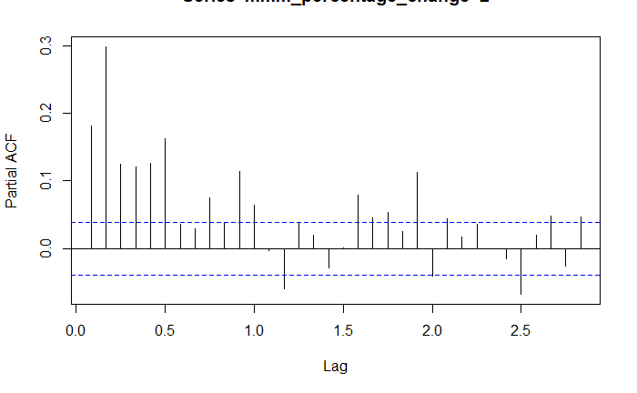

```r
# MMM
mmm_percentage_change <- ts(transformed_data.returns$returns.MMM, frequency = 12, start = 2008)
mmm_percentage_change_truncated <- window(mmm_percentage_change, start = 2013)
pacf(mmm_percentage_change^2)
```

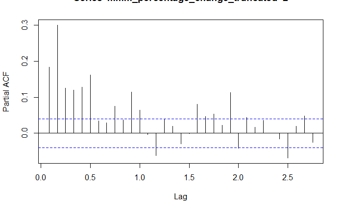

```r
pacf(mmm_percentage_change_truncated^2)
```

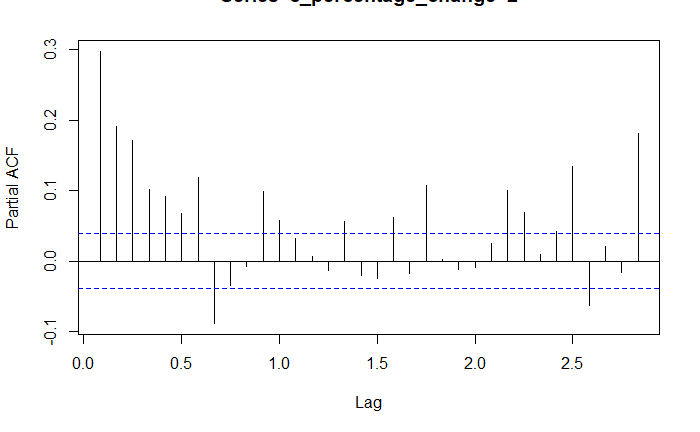

```r
# C
c_percentage_change <- ts(transformed_data.returns$returns.C, frequency = 12, start = 2008)
c_percentage_change_truncated <- window(c_percentage_change, start = 2013)
pacf(c_percentage_change^2)
```

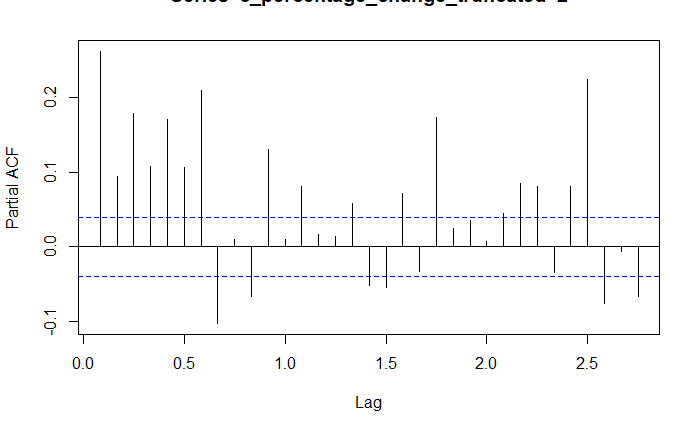

```r
pacf(c_percentage_change_truncated^2)
```

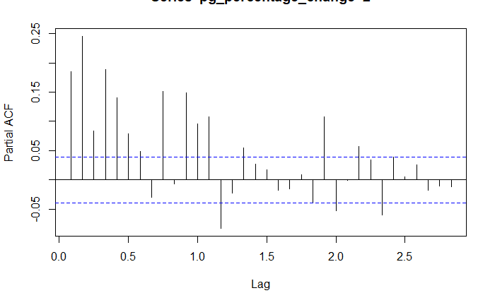

```r
# PG
pg_percentage_change <- ts(transformed_data.returns$returns.PG, frequency = 12, start = 2008)
pg_percentage_change_truncated <- window(pg_percentage_change, start = 2013)
pacf(pg_percentage_change^2)
```

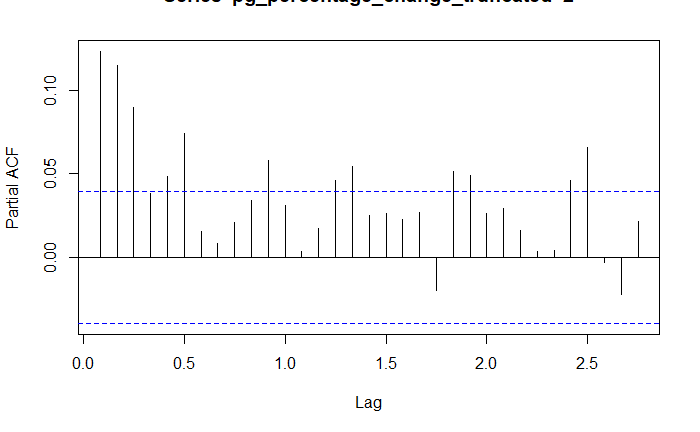

```r
pacf(pg_percentage_change_truncated^2)
```

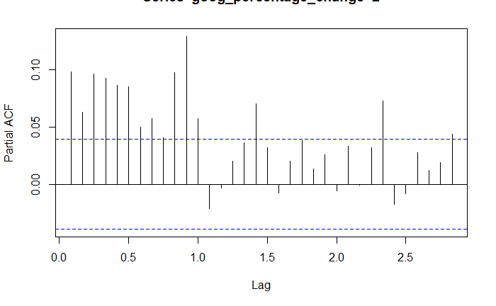

```r
# GOOG
goog_percentage_change <- ts(transformed_data.returns$returns.GOOG, frequency = 12, start = 2008)
goog_percentage_change_truncated <- window(goog_percentage_change, start = 2013)
pacf(goog_percentage_change^2)
```

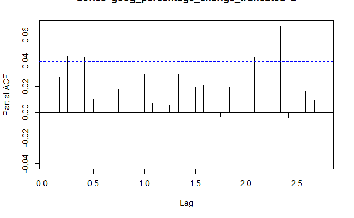

```r
pacf(goog_percentage_change_truncated^2)
```

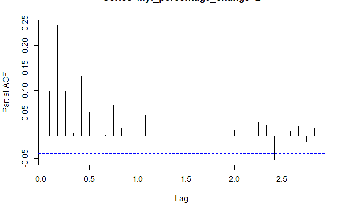

```r
# MYL
myl_percentage_change <- ts(transformed_data.returns$returns.MYL, frequency = 12, start = 2008)
myl_percentage_change_truncated <- window(myl_percentage_change, start = 2013)
pacf(myl_percentage_change^2)
```

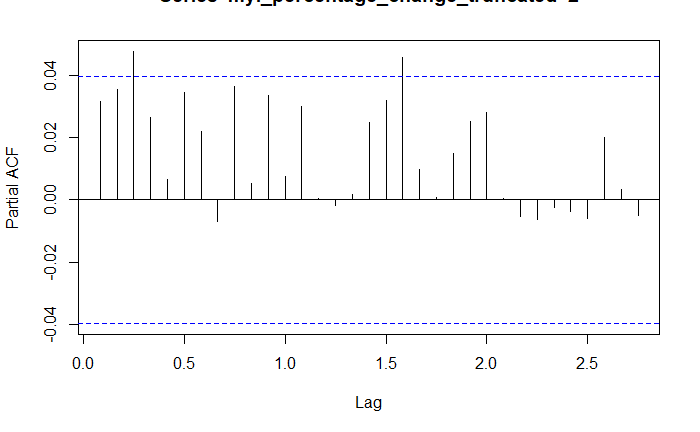

```r
pacf(myl_percentage_change_truncated^2)
```

Discussion: Similarities

Difference - MMM (Surya)

Both full and truncated version shows a similar result. There are strong lags on the quarter half of the half which suddenly decrease and become stable after that.

- C
- GOOG
- MYL
- PG

SECTION 2.3 - ARIMA MODEL Stationary analysis of the returns series

```r
# MMM
mmm_percentage_change <- ts(transformed_data.returns$returns.MMM, frequency = 12, start = 2008)
mmm_arma_model <- arma(window(mmm_percentage_change, start = 2008, end = 2018), order = c(12,0,0) )
summary(mmm_arma_model)
```

```
Call:
arma(x = window(mmm_percentage_change, start = 2008, end = 2018),     order = c(12, 0, 0))

Model:
ARMA(12,0)

Residuals:
       Min         1Q     Median         3Q        Max
-0.0324426 -0.0075725 -0.0009894  0.0069365  0.0357028

Coefficient(s):
            Estimate  Std. Error  t value Pr(>|t|)
ar1        0.0145113   0.0898988    0.161   0.8718
ar2       -0.0647369   0.0899230   -0.720   0.4716
ar3       -0.0979299   0.0907766   -1.079   0.2807
ar4        0.1297410   0.0949019    1.367   0.1716
ar5       -0.1549885   0.0950373   -1.631   0.1029
ar6       -0.0614024   0.0944583   -0.650   0.5157
ar7       -0.0450565   0.0941122   -0.479   0.6321
ar8       -0.0189136   0.0919360   -0.206   0.8370
ar9        0.0655022   0.0919659    0.712   0.4763
ar10      -0.0285652   0.0889823   -0.321   0.7482
ar11       0.0119657   0.0889045    0.135   0.8929
ar12       0.1893739   0.0891274    2.125   0.0336 *
intercept -0.0005619   0.0011256   -0.499   0.6176
---
Signif. codes:  0 ‘***’ 0.001 ‘**’ 0.01 ‘*’ 0.05 ‘.’ 0.1 ‘ ’ 1

Fit:
sigma^2 estimated as 0.0001506,  Conditional Sum-of-Squares = 0.02,  AIC = -695.53
```

```r
Box.test(mmm_arma_model$residuals, lag = 12)
```

```
    Box-Pierce test

data:  mmm_arma_model$residuals
X-squared = 2.1304, df = 12, p-value = 0.9992
```

```r
# Citi
citi_percentage_change <- ts(transformed_data.returns$returns.C, frequency = 12, start = 2008)
citi_arma_model <- arma(window(citi_percentage_change, start = 2008, end = 2018), order = c(12,0,0) )
summary(citi_arma_model)
```

```
Call:
arma(x = window(citi_percentage_change, start = 2008, end = 2018),     order = c(12, 0, 0))

Model:
ARMA(12,0)

Residuals:
      Min        1Q    Median        3Q       Max
-0.302880 -0.051461  0.001419  0.059792  0.454817

Coefficient(s):
            Estimate  Std. Error  t value Pr(>|t|)
ar1        0.0156695   0.0898282    0.174   0.8615
ar2       -0.0077968   0.0901904   -0.086   0.9311
ar3       -0.0394521   0.0902975   -0.437   0.6622
ar4       -0.2119590   0.0915374   -2.316   0.0206 *
ar5        0.0006166   0.0943380    0.007   0.9948
ar6       -0.1011711   0.0941963   -1.074   0.2828
ar7       -0.0198987   0.0949200   -0.210   0.8340
ar8       -0.0292726   0.0947978   -0.309   0.7575
ar9       -0.0961146   0.0920927   -1.044   0.2966
ar10      -0.0013918   0.0924316   -0.015   0.9880
ar11      -0.1133014   0.0933195   -1.214   0.2247
ar12      -0.0355866   0.0938663   -0.379   0.7046
intercept -0.0279216   0.0120132   -2.324   0.0201 *
---
Signif. codes:  0 ‘***’ 0.001 ‘**’ 0.01 ‘*’ 0.05 ‘.’ 0.1 ‘ ’ 1

Fit:
sigma^2 estimated as 0.01272,  Conditional Sum-of-Squares = 1.37,  AIC = -158.68
```

```r
Box.test(citi_arma_model$residuals, lag = 12)
```

```
    Box-Pierce test

data:  citi_arma_model$residuals
X-squared = 0.8854, df = 12, p-value = 1
```

```r
# P & G
pg_percentage_change <- ts(transformed_data.returns$returns.PG, frequency = 12, start = 2008)
pg_arma_model <- arma(window(pg_percentage_change, start = 2008, end = 2018), order = c(12,0,0) )
summary(pg_arma_model)
```

```
Call:
arma(x = window(pg_percentage_change, start = 2008, end = 2018),     order = c(12, 0, 0))

Model:
ARMA(12,0)

Residuals:
       Min         1Q     Median         3Q        Max
-7.166e-02 -1.437e-02 -5.889e-05  1.330e-02  6.798e-02

Coefficient(s):
           Estimate  Std. Error  t value Pr(>|t|)
ar1       -0.127964    0.089143   -1.435   0.1511
ar2       -0.351302    0.089388   -3.930 8.49e-05 ***
ar3        0.129405    0.094875    1.364   0.1726
ar4       -0.206723    0.093947   -2.200   0.0278 *
ar5       -0.062551    0.095569   -0.655   0.5128
ar6       -0.052074    0.095180   -0.547   0.5843
ar7       -0.110901    0.095170   -1.165   0.2439
ar8        0.075547    0.095569    0.791   0.4292
ar9       -0.178967    0.093333   -1.918   0.0552 .
ar10       0.124352    0.093957    1.324   0.1857
ar11      -0.110504    0.089892   -1.229   0.2190
ar12       0.197165    0.090001    2.191   0.0285 *
intercept -0.005439    0.002664   -2.041   0.0412 *
---
Signif. codes:  0 ‘***’ 0.001 ‘**’ 0.01 ‘*’ 0.05 ‘.’ 0.1 ‘ ’ 1

Fit:
sigma^2 estimated as 0.0005901,  Conditional Sum-of-Squares = 0.06,  AIC = -530.28
```

```r
Box.test(pg_arma_model$residuals, lag = 12)
```

```
    Box-Pierce test

data:  pg_arma_model$residuals
X-squared = 1.0749, df = 12, p-value = 1
```

```r
# Google
goog_percentage_change <- ts(transformed_data.returns$returns.GOOG, frequency = 12, start = 2008)
goog_arma_model <- arma(window(goog_percentage_change, start = 2008, end = 2018), order = c(12,0,0) )
summary(goog_arma_model)
```

```
Call:
arma(x = window(goog_percentage_change, start = 2008, end = 2018),     order = c(12, 0, 0))

Model:
ARMA(12,0)

Residuals:
       Min         1Q     Median         3Q        Max
-0.1113916 -0.0244762 -0.0002017  0.0257513  0.1201712

Coefficient(s):
           Estimate  Std. Error  t value Pr(>|t|)
ar1       -0.074930    0.088791   -0.844   0.3987
ar2       -0.065617    0.088548   -0.741   0.4587
ar3        0.019455    0.088022    0.221   0.8251
ar4       -0.060231    0.087361   -0.689   0.4905
ar5        0.002706    0.086499    0.031   0.9750
ar6       -0.031473    0.086231   -0.365   0.7151
ar7       -0.003360    0.086741   -0.039   0.9691
ar8        0.218926    0.086677    2.526   0.0115 *
ar9       -0.148542    0.087044   -1.707   0.0879 .
ar10      -0.111019    0.088068   -1.261   0.2074
ar11      -0.056751    0.088459   -0.642   0.5212
ar12       0.170000    0.088538    1.920   0.0548 .
intercept -0.002884    0.003564   -0.809   0.4184
---
Signif. codes:  0 ‘***’ 0.001 ‘**’ 0.01 ‘*’ 0.05 ‘.’ 0.1 ‘ ’ 1

Fit:
sigma^2 estimated as 0.001489,  Conditional Sum-of-Squares = 0.16,  AIC = -418.27
```

```r
Box.test(goog_arma_model$residuals, lag = 12)
```

```
    Box-Pierce test

data:  goog_arma_model$residuals
X-squared = 2.1882, df = 12, p-value = 0.9991
```

```r
# MYL
myl_percentage_change <- ts(transformed_data.returns$returns.MYL, frequency = 12, start = 2008)
myl_arma_model <- arma(window(myl_percentage_change, start = 2008, end = 2018), order = c(12,0,0) )
summary(myl_arma_model)
```

```
Call:
arma(x = window(myl_percentage_change, start = 2008, end = 2018),     order = c(12, 0, 0))

Model:
ARMA(12,0)

Residuals:
      Min        1Q    Median        3Q       Max
-0.159218 -0.028373 -0.000815  0.025062  0.192793

Coefficient(s):
            Estimate  Std. Error  t value Pr(>|t|)
ar1        0.1925776   0.0889799    2.164   0.0304 *
ar2       -0.1059335   0.0888914   -1.192   0.2334
ar3        0.1173492   0.0892931    1.314   0.1888
ar4       -0.1351307   0.0901116   -1.500   0.1337
ar5        0.0218342   0.0908577    0.240   0.8101
ar6       -0.0443907   0.0906198   -0.490   0.6242
ar7       -0.0597240   0.0904172   -0.661   0.5089
ar8        0.0335063   0.0883905    0.379   0.7046
ar9       -0.0564381   0.0877390   -0.643   0.5201
ar10       0.0578230   0.0876944    0.659   0.5097
ar11      -0.1872436   0.0876691   -2.136   0.0327 *
ar12       0.1818918   0.0879739    2.068   0.0387 *
intercept  0.0007502   0.0045092    0.166   0.8679
---
Signif. codes:  0 ‘***’ 0.001 ‘**’ 0.01 ‘*’ 0.05 ‘.’ 0.1 ‘ ’ 1

Fit:
sigma^2 estimated as 0.002476,  Conditional Sum-of-Squares = 0.27,  AIC = -356.74
```

```r
Box.test(myl_arma_model$residuals, lag = 12)
```

```
    Box-Pierce test

data:  myl_arma_model$residuals
X-squared = 1.369, df = 12, p-value = 0.9999
```

Discussion: - MMM (Surya)

Stationary analysis of the square of the returns series

```r
#MMM
mmm_percentage_change <- ts(transformed_data.returns$returns.MMM^2, frequency = 12, start = 2008)
mmm_arma_model <- arma(window(mmm_percentage_change, start = 2008, end = 2018), order = c(12,0,0) )
summary(mmm_arma_model)
```

```
Call:
arma(x = window(mmm_percentage_change, start = 2008, end = 2018),     order = c(12, 0, 0))

Model:
ARMA(12,0)

Residuals:
       Min         1Q     Median         3Q        Max
-2.593e-04 -1.375e-04 -8.267e-05  4.313e-05  1.031e-03

Coefficient(s):
            Estimate  Std. Error  t value Pr(>|t|)
ar1       -6.480e-02   9.049e-02   -0.716 0.473921
ar2       -3.830e-02   9.086e-02   -0.422 0.673344
ar3       -9.044e-02   9.082e-02   -0.996 0.319337
ar4       -9.063e-02   9.658e-02   -0.938 0.348027
ar5        5.976e-03   9.675e-02    0.062 0.950752
ar6        7.714e-02   9.170e-02    0.841 0.400204
ar7       -1.111e-02   9.199e-02   -0.121 0.903903
ar8       -4.366e-02   9.200e-02   -0.475 0.635102
ar9        3.953e-02   9.232e-02    0.428 0.668553
ar10      -4.680e-02   8.613e-02   -0.543 0.586921
ar11      -4.395e-02   8.635e-02   -0.509 0.610801
ar12      -6.493e-02   8.566e-02   -0.758 0.448412
intercept  2.317e-04   6.476e-05    3.577 0.000347 ***
---
Signif. codes:  0 ‘***’ 0.001 ‘**’ 0.01 ‘*’ 0.05 ‘.’ 0.1 ‘ ’ 1

Fit:
sigma^2 estimated as 5.772e-08,  Conditional Sum-of-Squares = 0,  AIC = -1647.4
```

```r
Box.test(mmm_arma_model$residuals, lag = 12)
```

```
    Box-Pierce test

data:  mmm_arma_model$residuals
X-squared = 1.5962, df = 12, p-value = 0.9998
```

```r
# Citi
citi_percentage_change <- ts(transformed_data.returns$returns.C^2, frequency = 12, start = 2008)
citi_arma_model <- arma(window(citi_percentage_change, start = 2008, end = 2018), order = c(12,0,0) )
summary(citi_arma_model)
```

```
Call:
arma(x = window(citi_percentage_change, start = 2008, end = 2018),     order = c(12, 0, 0))

Model:
ARMA(12,0)

Residuals:
      Min        1Q    Median        3Q       Max
-0.061610 -0.009673 -0.005568  0.003683  0.161272

Coefficient(s):
           Estimate  Std. Error  t value Pr(>|t|)
ar1        0.141974    0.091097    1.558  0.11911
ar2        0.260726    0.092265    2.826  0.00472 **
ar3        0.099952    0.094951    1.053  0.29249
ar4        0.020302    0.096839    0.210  0.83394
ar5       -0.052762    0.096715   -0.546  0.58538
ar6        0.017602    0.096990    0.181  0.85598
ar7       -0.013319    0.096959   -0.137  0.89074
ar8       -0.061361    0.097014   -0.632  0.52706
ar9       -0.043283    0.097219   -0.445  0.65617
ar10      -0.035301    0.096787   -0.365  0.71532
ar11      -0.007012    0.094471   -0.074  0.94083
ar12      -0.014828    0.093232   -0.159  0.87364
intercept  0.009528    0.003488    2.731  0.00631 **
---
Signif. codes:  0 ‘***’ 0.001 ‘**’ 0.01 ‘*’ 0.05 ‘.’ 0.1 ‘ ’ 1

Fit:
sigma^2 estimated as 0.0005946,  Conditional Sum-of-Squares = 0.06,  AIC = -529.36
```

```r
Box.test(citi_arma_model$residuals, lag = 12)
```

```
    Box-Pierce test

data:  citi_arma_model$residuals
X-squared = 0.1968, df = 12, p-value = 1
```

```r
# P & G
pg_percentage_change <- ts(transformed_data.returns$returns.PG^2, frequency = 12, start = 2008)
pg_arma_model <- arma(window(pg_percentage_change, start = 2008, end = 2018), order = c(12,0,0) )
summary(pg_arma_model)
```

```
Call:
arma(x = window(pg_percentage_change, start = 2008, end = 2018),     order = c(12, 0, 0))

Model:
ARMA(12,0)

Residuals:
       Min         1Q     Median         3Q        Max
-0.0020200 -0.0005957 -0.0002668  0.0002317  0.0070782

Coefficient(s):
            Estimate  Std. Error  t value Pr(>|t|)
ar1        0.0217533   0.0902252    0.241   0.8095
ar2        0.1118982   0.0888761    1.259   0.2080
ar3       -0.0304556   0.0890249   -0.342   0.7323
ar4        0.1849274   0.0882302    2.096   0.0361 *
ar5        0.0990457   0.0891763    1.111   0.2667
ar6        0.0520752   0.0895548    0.581   0.5609
ar7       -0.0401423   0.0895233   -0.448   0.6539
ar8       -0.1175043   0.0891432   -1.318   0.1875
ar9        0.1309813   0.0882602    1.484   0.1378
ar10      -0.0988277   0.0890254   -1.110   0.2670
ar11       0.1730075   0.0888389    1.947   0.0515 .
ar12       0.1251068   0.0901806    1.387   0.1654
intercept  0.0003062   0.0001920    1.595   0.1108
---
Signif. codes:  0 ‘***’ 0.001 ‘**’ 0.01 ‘*’ 0.05 ‘.’ 0.1 ‘ ’ 1

Fit:
sigma^2 estimated as 1.673e-06,  Conditional Sum-of-Squares = 0,  AIC = -1240
```

```r
Box.test(pg_arma_model$residuals, lag = 12)
```

```
    Box-Pierce test

data:  pg_arma_model$residuals
X-squared = 0.6873, df = 12, p-value = 1
```

```r
# Google
goog_percentage_change <- ts(transformed_data.returns$returns.GOOG^2, frequency = 12, start = 2008)
goog_arma_model <- arma(window(goog_percentage_change, start = 2008, end = 2018), order = c(12,0,0) )
summary(goog_arma_model)
```

```
Call:
arma(x = window(goog_percentage_change, start = 2008, end = 2018),     order = c(12, 0, 0))

Model:
ARMA(12,0)

Residuals:
       Min         1Q     Median         3Q        Max
-0.0038033 -0.0014094 -0.0006714  0.0004642  0.0151333

Coefficient(s):
            Estimate  Std. Error  t value Pr(>|t|)
ar1       -0.1357382   0.0897207   -1.513 0.130306
ar2       -0.0879018   0.0851736   -1.032 0.302057
ar3        0.0031792   0.0838486    0.038 0.969755
ar4       -0.0047535   0.0838111   -0.057 0.954770
ar5        0.0075570   0.0837100    0.090 0.928068
ar6        0.0836445   0.0836991    0.999 0.317627
ar7        0.0251652   0.0836267    0.301 0.763473
ar8        0.0112041   0.0836075    0.134 0.893396
ar9        0.0356526   0.0836383    0.426 0.669911
ar10       0.1919197   0.0837104    2.293 0.021868 *
ar11       0.3304719   0.0851134    3.883 0.000103 ***
ar12       0.1374415   0.0890351    1.544 0.122667
intercept  0.0006787   0.0005394    1.258 0.208302
---
Signif. codes:  0 ‘***’ 0.001 ‘**’ 0.01 ‘*’ 0.05 ‘.’ 0.1 ‘ ’ 1

Fit:
sigma^2 estimated as 7.273e-06,  Conditional Sum-of-Squares = 0,  AIC = -1062.21
```

```r
Box.test(goog_arma_model$residuals, lag = 12)
```

```
    Box-Pierce test

data:  goog_arma_model$residuals
X-squared = 1.5261, df = 12, p-value = 0.9999
```

```r
# MYL
myl_percentage_change <- ts(transformed_data.returns$returns.MYL^2, frequency = 12, start = 2008)
myl_arma_model <- arma(window(myl_percentage_change, start = 2008, end = 2018), order = c(12,0,0) )
summary(myl_arma_model)
```

```
Call:
arma(x = window(myl_percentage_change, start = 2008, end = 2018),     order = c(12, 0, 0))

Model:
ARMA(12,0)

Residuals:
       Min         1Q     Median         3Q        Max
-0.0099871 -0.0018227 -0.0007111  0.0008296  0.0300078

Coefficient(s):
            Estimate  Std. Error  t value Pr(>|t|)
ar1        0.0681011   0.0904834    0.753 0.451668
ar2        0.4851143   0.0878311    5.523 3.33e-08 ***
ar3       -0.0065975   0.0979222   -0.067 0.946283
ar4       -0.3243027   0.0983586   -3.297 0.000977 ***
ar5        0.2407870   0.1024121    2.351 0.018715 *
ar6        0.1178138   0.1031777    1.142 0.253515
ar7        0.0473189   0.1035042    0.457 0.647550
ar8       -0.1050498   0.0981495   -1.070 0.284483
ar9       -0.0068142   0.0953029   -0.072 0.943000
ar10       0.0199553   0.0943782    0.211 0.832544
ar11       0.2446159   0.0855662    2.859 0.004253 **
ar12      -0.0803309   0.0882804   -0.910 0.362848
intercept  0.0007981   0.0006148    1.298 0.194239
---
Signif. codes:  0 ‘***’ 0.001 ‘**’ 0.01 ‘*’ 0.05 ‘.’ 0.1 ‘ ’ 1

Fit:
sigma^2 estimated as 2.254e-05,  Conditional Sum-of-Squares = 0,  AIC = -925.36
```

```r
Box.test(myl_arma_model$residuals, lag = 12)
```

```
    Box-Pierce test

data:  myl_arma_model$residuals
X-squared = 2.7062, df = 12, p-value = 0.9973
```

Discussion: - MMM (Surya)